# Final Assignment

Task A.1 — Load dataset and A.1.1 Import libraries

```python
import pandas as pd
import numpy as np
import matplotlib.pyplot as plt
```

A.1.2 Load the CSV file

```python
file_path = "iot_telemetry_data.csv"
df = pd.read_csv(file_path)

df.head()
```

|  | ts | device | co | humidity | light | lpg | motion | smoke | temp |
| --- | --- | --- | --- | --- | --- | --- | --- | --- | --- |
| 0 | 1.594512e+09 | b8:27:eb:bf:9d:51 | 0.004956 | 51.000000 | False | 0.007651 | False | 0.020411 | 22.700000 |
| 1 | 1.594512e+09 | 00:0f:00:70:91:0a | 0.002840 | 76.000000 | False | 0.005114 | False | 0.013275 | 19.700001 |
| 2 | 1.594512e+09 | b8:27:eb:bf:9d:51 | 0.004976 | 50.900000 | False | 0.007673 | False | 0.020475 | 22.600000 |
| 3 | 1.594512e+09 | 1c:bf:ce:15:ec:4d | 0.004403 | 76.800003 | True | 0.007023 | False | 0.018628 | 27.000000 |
| 4 | 1.594512e+09 | b8:27:eb:bf:9d:51 | 0.004967 | 50.900000 | False | 0.007664 | False | 0.020448 | 22.600000 |

A.1.3 Basic dataset overview (dimensions, columns)

```python
print("Shape (rows, columns):", df.shape)
print("\nColumns:", df.columns.tolist())
```

```
Shape (rows, columns): (405184, 9)

Columns: ['ts', 'device', 'co', 'humidity', 'light', 'lpg', 'motion', 'smoke', 'temp']
```

A.1.4 Data types + quick info

```python
df.info()
```

```
<class 'pandas.core.frame.DataFrame'>
RangeIndex: 405184 entries, 0 to 405183
Data columns (total 9 columns):
 #   Column    Non-Null Count   Dtype
---  ------    --------------   -----
 0   ts        405184 non-null  float64
 1   device    405184 non-null  object
 2   co        405184 non-null  float64
 3   humidity  405184 non-null  float64
 4   light     405184 non-null  bool
 5   lpg       405184 non-null  float64
 6   motion    405184 non-null  bool
 7   smoke     405184 non-null  float64
 8   temp      405184 non-null  float64
dtypes: bool(2), float64(6), object(1)
memory usage: 22.4+ MB
```

A.1.5 Convert ts to datetime + sort by time

```python
df["ts"] = pd.to_datetime(df["ts"], unit="s", errors="coerce")  # assuming UNIX seconds
df = df.sort_values("ts").reset_index(drop=True)

df[["ts"]].head(), df[["ts"]].tail()
```

```
(                             ts
 0 2020-07-12 00:01:34.385974646
 1 2020-07-12 00:01:34.735567570
 2 2020-07-12 00:01:38.073572874
 3 2020-07-12 00:01:39.589145899
 4 2020-07-12 00:01:41.761234999,
                                   ts
 405179 2020-07-20 00:03:33.162014961
 405180 2020-07-20 00:03:33.576560736
 405181 2020-07-20 00:03:36.167959213
 405182 2020-07-20 00:03:36.979521513
 405183 2020-07-20 00:03:37.264312506)
```

A.1.6 Time range (required in overview)

```python
time_min = df["ts"].min()
time_max = df["ts"].max()

print("Time range:")
print("Start:", time_min)
print("End:  ", time_max)
print("Total duration:", time_max - time_min)
```

```
Time range:
Start: 2020-07-12 00:01:34.385974646
End:   2020-07-20 00:03:37.264312506
Total duration: 8 days 00:02:02.878337860
```

A.1.7 Missing values per column

```python
missing_counts = df.isna().sum()
missing_percent = (missing_counts / len(df)) * 100

missing_summary = pd.DataFrame({
    "missing_count": missing_counts,
    "missing_percent": missing_percent
}).sort_values("missing_percent", ascending=False)

missing_summary
```

|  | missing_count | missing_percent |
| --- | --- | --- |
| ts | 0 | 0.0 |
| device | 0 | 0.0 |
| co | 0 | 0.0 |
| humidity | 0 | 0.0 |
| light | 0 | 0.0 |
| lpg | 0 | 0.0 |
| motion | 0 | 0.0 |
| smoke | 0 | 0.0 |
| temp | 0 | 0.0 |

A.1.8 Estimate sampling rate

```python
dt_seconds = df["ts"].diff().dt.total_seconds()

print("Time difference stats (seconds):")
print(dt_seconds.describe())

print("\nMost common time steps (top 10):")
print(dt_seconds.value_counts().head(10))
```

```
Time difference stats (seconds):
count    405183.000000
mean          1.706199
std           1.139390
min           0.000000
25%           0.711421
50%           1.548439
75%           2.627533
max           5.806887
Name: ts, dtype: float64

Most common time steps (top 10):
ts
3.686065    16
3.685997    14
3.685920    14
0.000000    13
3.686001    13
3.685947    13
3.685923    12
3.686024    12
3.686002    12
3.685884    12
Name: count, dtype: int64
```

Task A.2 — Basic Statistical Analysis

A.2.1 Identify numeric & categorical columns

```python
#First, we separate numeric columns from categorical ones.
numeric_cols = df.select_dtypes(include=[np.number]).columns.tolist()
categorical_cols = df.select_dtypes(exclude=[np.number]).columns.tolist()

print("Numeric columns:", numeric_cols)
print("Categorical columns:", categorical_cols)
```

```
Numeric columns: ['co', 'humidity', 'lpg', 'smoke', 'temp']
Categorical columns: ['ts', 'device', 'light', 'motion']
```

A.2.2 Descriptive statistics (mean, std, min, max)

```python
df[numeric_cols].describe().T
```

|  | count | mean | std | min | 25% | 50% | 75% | max |
| --- | --- | --- | --- | --- | --- | --- | --- | --- |
| co | 405184.0 | 0.004639 | 0.001250 | 0.001171 | 0.003919 | 0.004812 | 0.005409 | 0.014420 |
| humidity | 405184.0 | 60.511694 | 11.366489 | 1.100000 | 51.000000 | 54.900000 | 74.300003 | 99.900002 |
| lpg | 405184.0 | 0.007237 | 0.001444 | 0.002693 | 0.006456 | 0.007489 | 0.008150 | 0.016567 |
| smoke | 405184.0 | 0.019264 | 0.004086 | 0.006692 | 0.017024 | 0.019950 | 0.021838 | 0.046590 |
| temp | 405184.0 | 22.453987 | 2.698347 | 0.000000 | 19.900000 | 22.200000 | 23.600000 | 30.600000 |

A.2.3 Extended quantile analysis (outlier detection)

```python
#We calculate 1%, 5%, 50%, 95%, 99% quantiles.
quantiles = df[numeric_cols].quantile([0.01, 0.05, 0.50, 0.95, 0.99]).T
quantiles
```

|  | 0.01 | 0.05 | 0.50 | 0.95 | 0.99 |
| --- | --- | --- | --- | --- | --- |
| co | 0.001463 | 0.002474 | 0.004812 | 0.006248 | 0.007518 |
| humidity | 46.700000 | 48.300000 | 54.900000 | 77.400002 | 80.099998 |
| lpg | 0.003165 | 0.004628 | 0.007489 | 0.009047 | 0.010342 |
| smoke | 0.007952 | 0.011930 | 0.019950 | 0.024414 | 0.028165 |
| temp | 18.799999 | 19.000000 | 22.200000 | 28.000000 | 29.600000 |

A.2.4 Per-device statistics (important for IoT data)

```python
device_stats = (
    df
    .groupby("device")[numeric_cols]
    .agg(["mean", "std", "min", "max"])
)

device_stats
```

| device | co mean | co std | co min | co max | humidity mean | humidity std | humidity min | humidity max | lpg mean | lpg std | lpg min | lpg max | smoke mean | smoke std | smoke min | smoke max | temp mean | temp std | temp min | temp max |
| --- | --- | --- | --- | --- | --- | --- | --- | --- | --- | --- | --- | --- | --- | --- | --- | --- | --- | --- | --- | --- |
| 00:0f:00:70:91:0a | 0.003527 | 0.001479 | 0.001171 | 0.014420 | 75.444361 | 1.975801 | 1.1 | 99.900002 | 0.005893 | 0.001700 | 0.002693 | 0.016567 | 0.015489 | 0.004809 | 0.006692 | 0.046590 | 19.362552 | 0.643786 | 0.0 | 20.200001 |
| 1c:bf:ce:15:ec:4d | 0.004183 | 0.000320 | 0.003391 | 0.006224 | 61.910247 | 8.944792 | 1.6 | 92.000000 | 0.006764 | 0.000373 | 0.005814 | 0.009022 | 0.017895 | 0.001055 | 0.015224 | 0.024341 | 26.025511 | 2.026427 | 0.0 | 30.600000 |
| b8:27:eb:bf:9d:51 | 0.005560 | 0.000559 | 0.004646 | 0.007955 | 50.814077 | 1.888926 | 45.1 | 63.300000 | 0.008306 | 0.000599 | 0.007301 | 0.010774 | 0.022288 | 0.001720 | 0.019416 | 0.029422 | 22.279969 | 0.481902 | 21.0 | 24.100000 |

A.2.5 Event-based statistics (light vs motion)

```python
#Our dataset contains binary event columns.
motion_rate = df.groupby("device")["motion"].mean()
motion_rate
```

```
device
00:0f:00:70:91:0a    0.000027
1c:bf:ce:15:ec:4d    0.003163
b8:27:eb:bf:9d:51    0.000768
Name: motion, dtype: float64
```

Light ON probability per device

```python
light_on_rate = df.groupby("device")["light"].mean()
light_on_rate
```

```
device
00:0f:00:70:91:0a    0.032268
1c:bf:ce:15:ec:4d    1.000000
b8:27:eb:bf:9d:51    0.016010
Name: light, dtype: float64
```

A.2.6 Time-based aggregation (hourly & daily patterns)

```python
df["hour"] = df["ts"].dt.hour

hourly_stats = (
    df
    .groupby("hour")[numeric_cols]
    .mean()
)

hourly_stats.head()
```

| hour | co | humidity | lpg | smoke | temp |
| --- | --- | --- | --- | --- | --- |
| 0 | 0.005240 | 60.267719 | 0.007901 | 0.021158 | 22.776970 |
| 1 | 0.004957 | 60.295379 | 0.007602 | 0.020298 | 22.708430 |
| 2 | 0.004781 | 60.106194 | 0.007410 | 0.019749 | 22.690392 |
| 3 | 0.004642 | 60.187292 | 0.007254 | 0.019305 | 22.636431 |
| 4 | 0.004516 | 60.282283 | 0.007107 | 0.018889 | 22.564248 |

```python
#Daily aggregation
df["date"] = df["ts"].dt.date

daily_stats = (
    df
    .groupby("date")[numeric_cols]
    .mean()
)

daily_stats.head()
```

| date | co | humidity | lpg | smoke | temp |
| --- | --- | --- | --- | --- | --- |
| 2020-07-12 | 0.004494 | 61.898795 | 0.007074 | 0.018799 | 22.274593 |
| 2020-07-13 | 0.004866 | 59.882391 | 0.007531 | 0.020079 | 21.981636 |
| 2020-07-14 | 0.004587 | 59.792232 | 0.007223 | 0.019201 | 22.309407 |
| 2020-07-15 | 0.004418 | 57.955801 | 0.007000 | 0.018582 | 22.866575 |
| 2020-07-16 | 0.004800 | 59.422866 | 0.007404 | 0.019745 | 22.438689 |

A.2.7 Quick sanity checks (data quality signals)

```python
print("Negative values check:")
(df[numeric_cols] < 0).sum()
```

```
Negative values check:
```

```
co          0
humidity    0
lpg         0
smoke       0
temp        0
dtype: int64
```

```python
print("Zero-only columns:")
(df[numeric_cols].nunique() == 1)
```

```
Zero-only columns:
```

```
co          False
humidity    False
lpg         False
smoke       False
temp        False
dtype: bool
```

Task A.3 — Data Quality Visualization

```python
#shows where missing values occur over time
import seaborn as sns
```

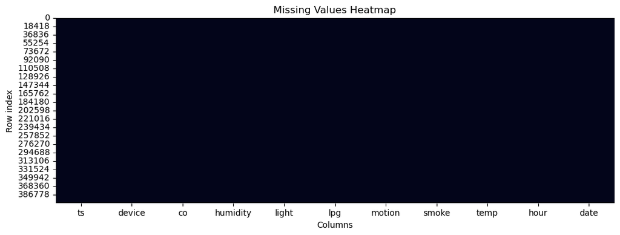

```python
plt.figure(figsize=(12, 4))
sns.heatmap(df.isna(), cbar=False)
plt.title("Missing Values Heatmap")
plt.xlabel("Columns")
plt.ylabel("Row index")
plt.show()
```

A.3.2 Missing values percentage bar plot

[figure not shown]

```python
missing_percent.sort_values(ascending=False).plot(
    kind="bar",
    figsize=(10, 4),
    title="Missing Values Percentage per Column"
)
plt.ylabel("Percentage (%)")
plt.show()
```

A.3.3 Distribution plots (numeric features)

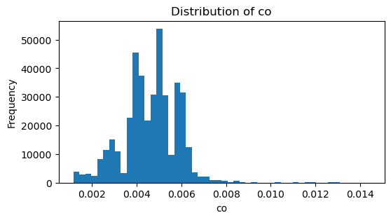

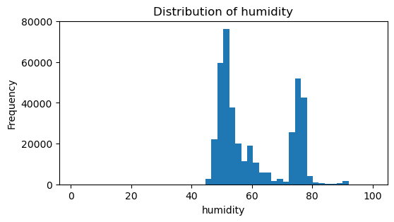

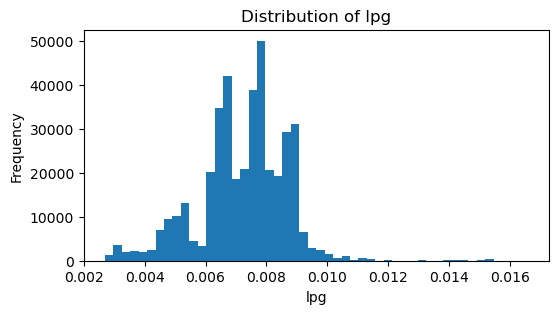

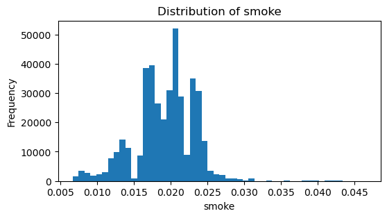

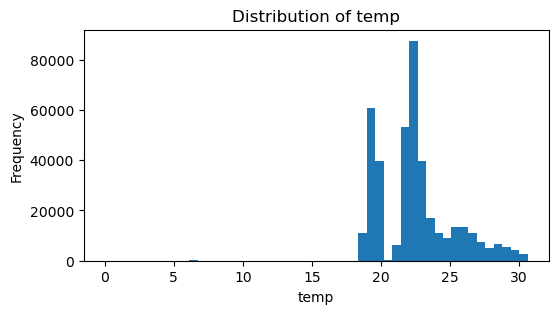

```python
#We inspect shape, skewness, and outliers.
for col in numeric_cols:
    plt.figure(figsize=(6, 3))
    plt.hist(df[col].dropna(), bins=50)
    plt.title(f"Distribution of {col}")
    plt.xlabel(col)
    plt.ylabel("Frequency")
    plt.show()
```

A.3.4 Boxplots (outlier detection)

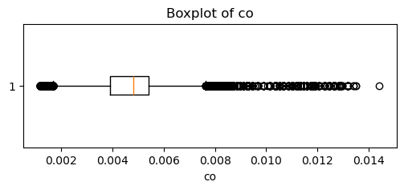

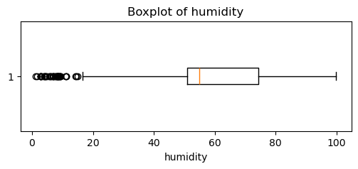

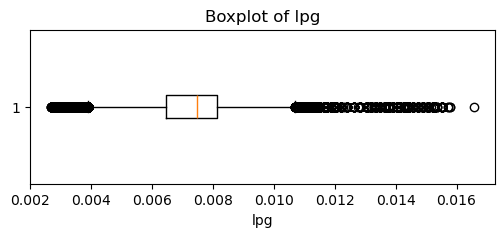

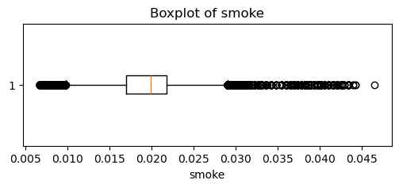

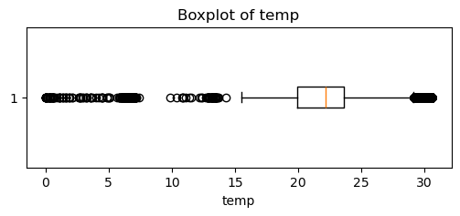

```python
for col in numeric_cols:
    plt.figure(figsize=(6, 2))
    plt.boxplot(df[col].dropna(), vert=False)
    plt.title(f"Boxplot of {col}")
    plt.xlabel(col)
    plt.show()
```

A.3.5 Time-series sanity check (sensor drift & spikes)

```
['co', 'humidity', 'lpg', 'smoke', 'temp']
```

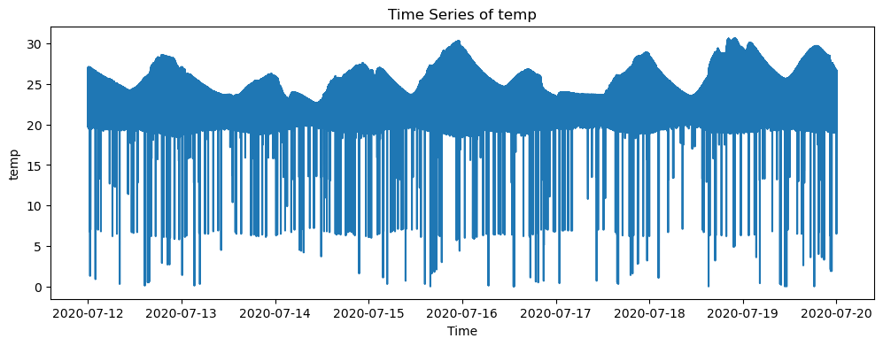

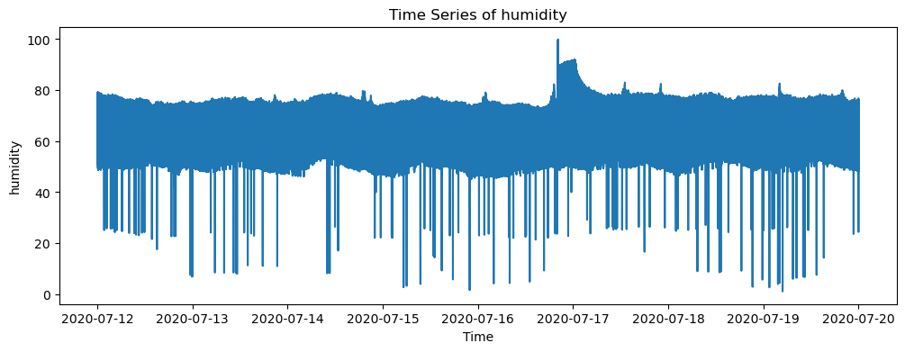

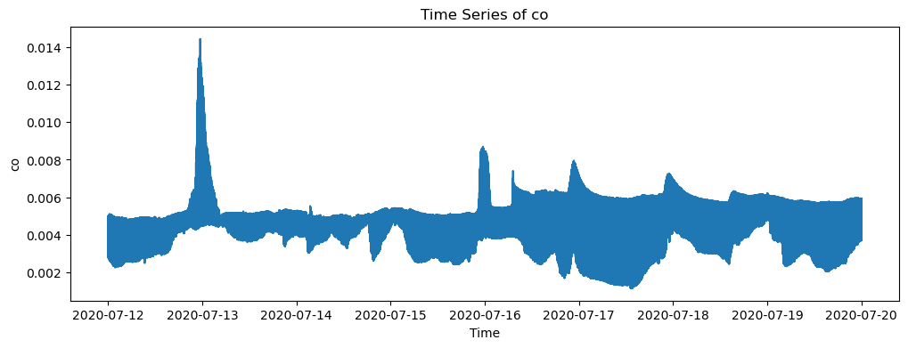

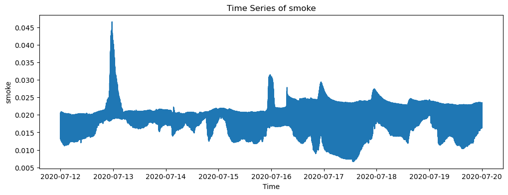

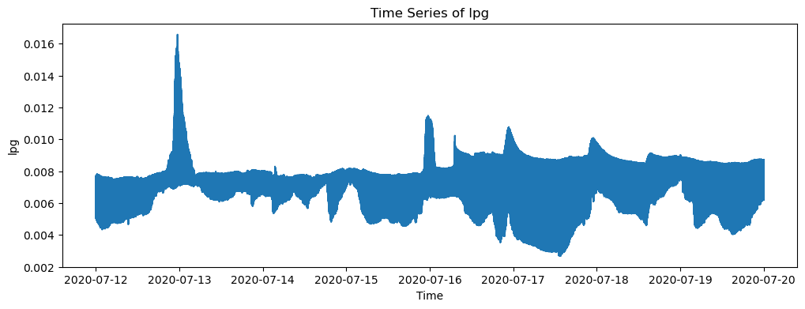

```python
#Plot key sensors over time.
print(numeric_cols) #Check available numeric sensor columns

sensor_cols = ["temp", "humidity", "co", "smoke", "lpg"]


for col in sensor_cols:
    plt.figure(figsize=(12, 4))
    plt.plot(df["ts"], df[col])
    plt.title(f"Time Series of {col}")
    plt.xlabel("Time")
    plt.ylabel(col)
    plt.show()
```

A.3.6 Event frequency visualization

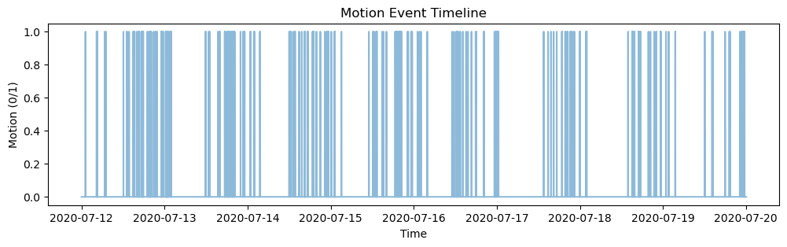

```python
plt.figure(figsize=(12, 3))
plt.plot(df["ts"], df["motion"], alpha=0.5)
plt.title("Motion Event Timeline")
plt.xlabel("Time")
plt.ylabel("Motion (0/1)")
plt.show()
```

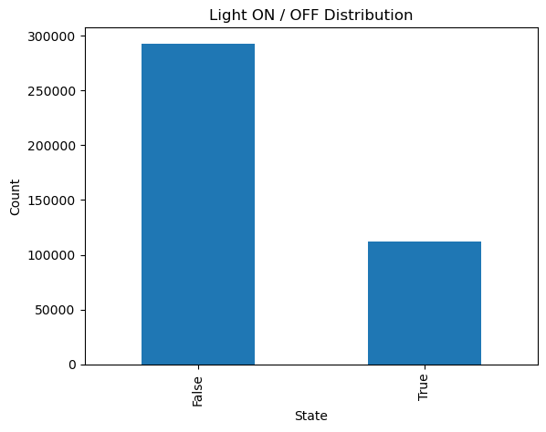

```python
#Light state distribution
df["light"].value_counts().plot(kind="bar")
plt.title("Light ON / OFF Distribution")
plt.xlabel("State")
plt.ylabel("Count")
plt.show()
```

A.3.7 Per-device sensor comparison (spot anomalies)

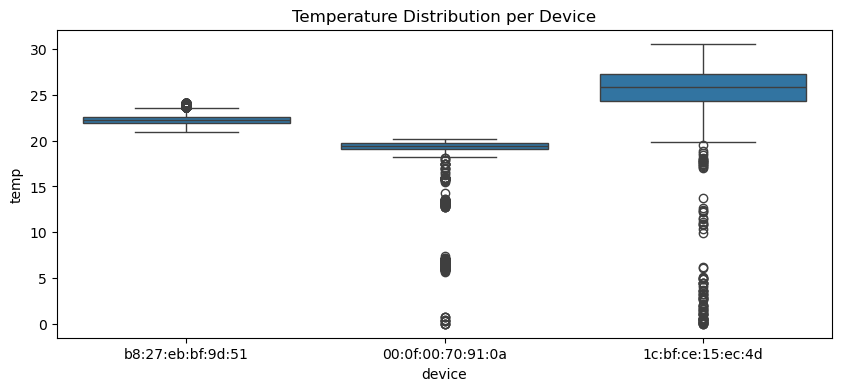

```python
plt.figure(figsize=(10, 4))
sns.boxplot(data=df, x="device", y="temp")
plt.title("Temperature Distribution per Device")
plt.show()
```

Task A.4 — Data Cleaning & Preprocessing

```python
df_clean = df.copy()
```

A.4.2 Handle missing values (sensor data)

```python
df_clean.isna().sum() #Check missing values again
```

```
ts          0
device      0
co          0
humidity    0
light       0
lpg         0
motion      0
smoke       0
temp        0
hour        0
date        0
dtype: int64
```

```python
numeric_sensor_cols = ["temp", "humidity", "co", "smoke", "lpg"]

df_clean[numeric_sensor_cols] = (
    df_clean[numeric_sensor_cols]
    .ffill()
    .bfill()
)
```

```python
event_cols = ["motion", "light"]

df_clean[event_cols] = df_clean[event_cols].fillna(0)
```

```python
#Categorical column
df_clean["device"] = df_clean["device"].fillna(df_clean["device"].mode()[0])
```

A.4.3 Verify missing values are gone

```python
df_clean.isna().sum()
```

```
ts          0
device      0
co          0
humidity    0
light       0
lpg         0
motion      0
smoke       0
temp        0
hour        0
date        0
dtype: int64
```

A.4.4 Outlier handling (robust & explainable)

```python
def clip_outliers(series, lower_q=0.01, upper_q=0.99):
    lower = series.quantile(lower_q)
    upper = series.quantile(upper_q)
    return series.clip(lower, upper)
```

```python
#Apply Clipping
for col in numeric_sensor_cols:
    df_clean[col] = clip_outliers(df_clean[col])
```

A.4.5 Encode categorical variables

```python
from sklearn.preprocessing import LabelEncoder

le_device = LabelEncoder()
df_clean["device_encoded"] = le_device.fit_transform(df_clean["device"])
```

A.4.6 Feature scaling (CRITICAL for ML)

```python
from sklearn.preprocessing import StandardScaler

scaler = StandardScaler()

scaled_features = scaler.fit_transform(df_clean[numeric_sensor_cols])

df_scaled = pd.DataFrame(
    scaled_features,
    columns=[f"{c}_scaled" for c in numeric_sensor_cols]
)

df_clean = pd.concat([df_clean.reset_index(drop=True), df_scaled], axis=1)
```

A.4.7 Final ML-ready dataset preview

```python
df_clean.head()
```

|  | ts | device | co | humidity | light | lpg | motion | smoke | temp | hour | date | device_encoded | temp_scaled | humidity_scaled | co_scaled | smoke_scaled | lpg_scaled |
| --- | --- | --- | --- | --- | --- | --- | --- | --- | --- | --- | --- | --- | --- | --- | --- | --- | --- |
| 0 | 2020-07-12 00:01:34.385974646 | b8:27:eb:bf:9d:51 | 0.004956 | 51.000000 | False | 0.007651 | False | 0.020411 | 22.700000 | 0 | 2020-07-12 | 2 | 0.090970 | -0.844720 | 0.279703 | 0.302605 | 0.307344 |
| 1 | 2020-07-12 00:01:34.735567570 | 00:0f:00:70:91:0a | 0.002840 | 76.000000 | False | 0.005114 | False | 0.013275 | 19.700001 | 0 | 2020-07-12 | 0 | -1.042023 | 1.388682 | -1.503582 | -1.516787 | -1.518658 |
| 2 | 2020-07-12 00:01:38.073572874 | b8:27:eb:bf:9d:51 | 0.004976 | 50.900000 | False | 0.007673 | False | 0.020475 | 22.600000 | 0 | 2020-07-12 | 2 | 0.053204 | -0.853654 | 0.296622 | 0.318884 | 0.323474 |
| 3 | 2020-07-12 00:01:39.589145899 | 1c:bf:ce:15:ec:4d | 0.004403 | 76.800003 | True | 0.007023 | False | 0.018628 | 27.000000 | 0 | 2020-07-12 | 1 | 1.714927 | 1.460151 | -0.186303 | -0.151972 | -0.144387 |
| 4 | 2020-07-12 00:01:41.761234999 | b8:27:eb:bf:9d:51 | 0.004967 | 50.900000 | False | 0.007664 | False | 0.020448 | 22.600000 | 0 | 2020-07-12 | 2 | 0.053204 | -0.853654 | 0.289332 | 0.311872 | 0.316527 |

```python
print("Final shape:", df_clean.shape)
```

```
Final shape: (405184, 17)
```

A.5.1 Numeric summary: before vs after

```python
df[numeric_sensor_cols].describe().T
```

|  | count | mean | std | min | 25% | 50% | 75% | max |
| --- | --- | --- | --- | --- | --- | --- | --- | --- |
| temp | 405184.0 | 22.453987 | 2.698347 | 0.000000 | 19.900000 | 22.200000 | 23.600000 | 30.600000 |
| humidity | 405184.0 | 60.511694 | 11.366489 | 1.100000 | 51.000000 | 54.900000 | 74.300003 | 99.900002 |
| co | 405184.0 | 0.004639 | 0.001250 | 0.001171 | 0.003919 | 0.004812 | 0.005409 | 0.014420 |
| smoke | 405184.0 | 0.019264 | 0.004086 | 0.006692 | 0.017024 | 0.019950 | 0.021838 | 0.046590 |
| lpg | 405184.0 | 0.007237 | 0.001444 | 0.002693 | 0.006456 | 0.007489 | 0.008150 | 0.016567 |

```python
df_clean[numeric_sensor_cols].describe().T
```

|  | count | mean | std | min | 25% | 50% | 75% | max |
| --- | --- | --- | --- | --- | --- | --- | --- | --- |
| temp | 405184.0 | 22.459125 | 2.647857 | 18.799999 | 19.900000 | 22.200000 | 23.600000 | 29.600000 |
| humidity | 405184.0 | 60.455533 | 11.193698 | 46.700000 | 51.000000 | 54.900000 | 74.300003 | 80.099998 |
| co | 405184.0 | 0.004624 | 0.001186 | 0.001463 | 0.003919 | 0.004812 | 0.005409 | 0.007518 |
| smoke | 405184.0 | 0.019224 | 0.003922 | 0.007952 | 0.017024 | 0.019950 | 0.021838 | 0.028165 |
| lpg | 405184.0 | 0.007224 | 0.001389 | 0.003165 | 0.006456 | 0.007489 | 0.008150 | 0.010342 |

A.5.2 Distribution comparison (histograms)

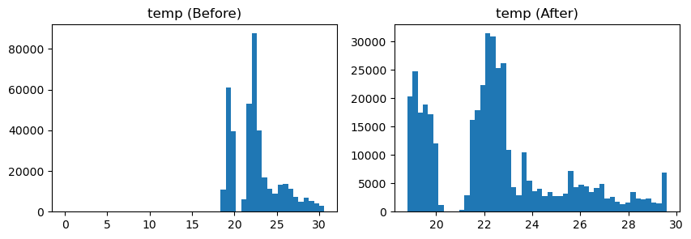

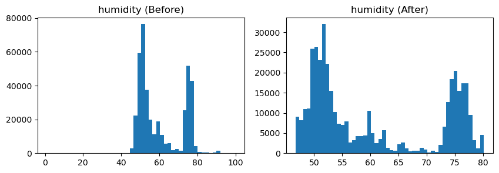

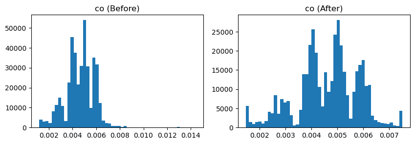

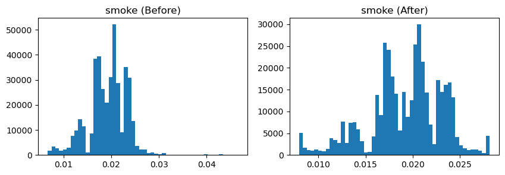

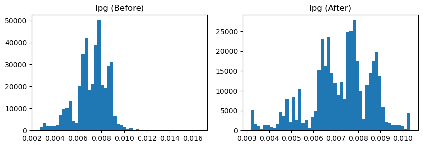

```python
for col in numeric_sensor_cols:
    plt.figure(figsize=(10, 3))

    plt.subplot(1, 2, 1)
    plt.hist(df[col].dropna(), bins=50)
    plt.title(f"{col} (Before)")

    plt.subplot(1, 2, 2)
    plt.hist(df_clean[col].dropna(), bins=50)
    plt.title(f"{col} (After)")

    plt.show()
```

A.5.3 Boxplot comparison (outliers)

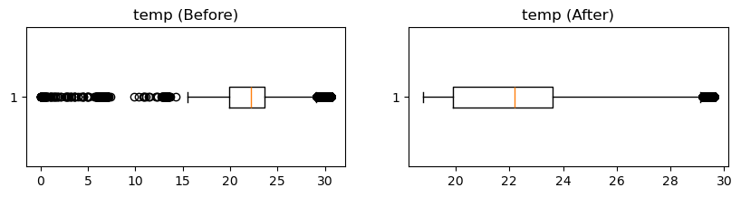

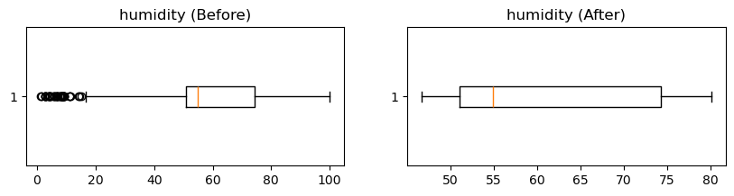

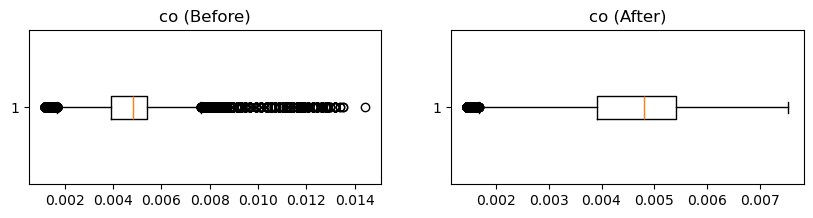

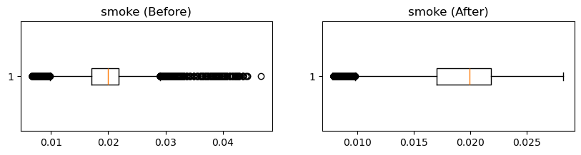

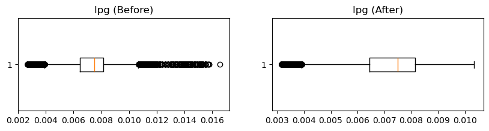

```python
for col in numeric_sensor_cols:
    plt.figure(figsize=(10, 2))

    plt.subplot(1, 2, 1)
    plt.boxplot(df[col].dropna(), vert=False)
    plt.title(f"{col} (Before)")

    plt.subplot(1, 2, 2)
    plt.boxplot(df_clean[col].dropna(), vert=False)
    plt.title(f"{col} (After)")

    plt.show()
```

A.5.4 Missing values comparison

```python
print("Missing values BEFORE cleaning:")
print(df.isna().sum())

print("\nMissing values AFTER cleaning:")
print(df_clean.isna().sum())
```

```
Missing values BEFORE cleaning:
ts          0
device      0
co          0
humidity    0
light       0
lpg         0
motion      0
smoke       0
temp        0
hour        0
date        0
dtype: int64

Missing values AFTER cleaning:
ts                 0
device             0
co                 0
humidity           0
light              0
lpg                0
motion             0
smoke              0
temp               0
hour               0
date               0
device_encoded     0
temp_scaled        0
humidity_scaled    0
co_scaled          0
smoke_scaled       0
lpg_scaled         0
dtype: int64
```

A.5.5 Time-series stability check

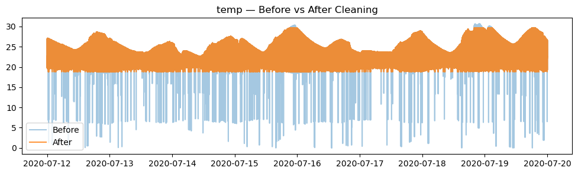

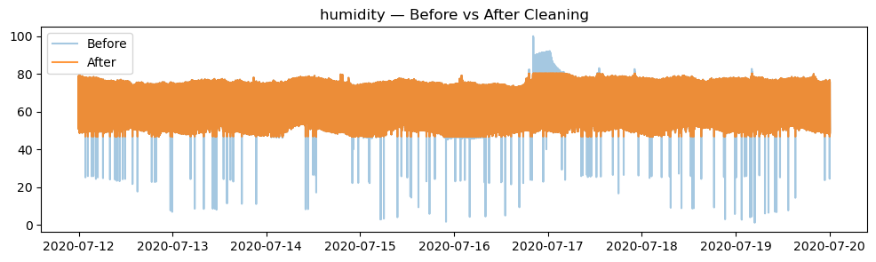

```python
for col in ["temp", "humidity"]:
    plt.figure(figsize=(12, 3))
    plt.plot(df["ts"], df[col], alpha=0.4, label="Before")
    plt.plot(df_clean["ts"], df_clean[col], alpha=0.8, label="After")
    plt.title(f"{col} — Before vs After Cleaning")
    plt.legend()
    plt.show()
```

A.5.6 Save the clean dataset

```python
df_clean.to_csv("iot_telemetry_data_cleaned.csv", index=False)
```